# Tic-Tac-Toe via Monte-Carlo Methods

```python
import mc_agents
import base_agent
import td_agent

from collections import defaultdict
from gym_tictactoe.env import TicTacToeEnv, set_log_level_by, agent_by_mark,\
    next_mark, check_game_status, after_action_state, O_REWARD, X_REWARD
```

## Initialize the Tic-Tac-Toe environment

```python
env = TicTacToeEnv(show_number=True)
```

### Plotting Functions

```python
import numpy as np
import matplotlib.pyplot as plt

def plot_mean_and_CI(mean, lb, ub, color_mean=None, color_shading=None):
    # plot the shaded range of the confidence intervals
    plt.fill_between(range(mean.shape[0]),ub, lb,
                     color=color_shading, alpha=.5)
    # plot the mean on top
    plt.plot(mean, color_mean)

def plot_mean_and_CI_2(a,mean, lb, ub, color_mean=None, color_shading=None):
    # plot the shaded range of the confidence intervals
    plt.fill_between(a, ub, lb,
                     color=color_shading, alpha=.5)
    # plot the mean on top
    plt.plot(a,mean, color_mean)

def plotting(returns,window_size = 100):
    averaged_returns = np.zeros(len(returns)-window_size+1)
    max_returns = np.zeros(len(returns)-window_size+1)
    min_returns = np.zeros(len(returns)-window_size+1)


    for i in range(len(averaged_returns)):
      averaged_returns[i] = np.mean(returns[i:i+window_size])
      max_returns[i] = np.max(returns[i:i+window_size])
      min_returns[i] = np.min(returns[i:i+window_size])

#     plt.plot(averaged_returns)

#     plot_mean_and_CI(averaged_returns,min_returns,max_returns,'g--','g')

    return (averaged_returns,max_returns,min_returns)


def plotting_2(returns,window_size = 100):
    averaged_returns = np.zeros(len(returns))
    max_returns = np.zeros(len(returns))
    min_returns = np.zeros(len(returns))


    for i in range(len(averaged_returns)-window_size+1):
      averaged_returns[i] = np.mean(returns[i:i+window_size])
      max_returns[i] = np.max(returns[i:i+window_size])
      min_returns[i] = np.min(returns[i:i+window_size])

    for i in range(len(averaged_returns)-window_size+1,len(averaged_returns)):
      averaged_returns[i] = np.mean(returns[i:])
      max_returns[i] = np.max(returns[i:])
      min_returns[i] = np.min(returns[i:])
#     plt.plot(averaged_returns)

#     plot_mean_and_CI(averaged_returns,min_returns,max_returns,'g--','g')

    return (averaged_returns,max_returns,min_returns)


def Q_sa_estimator(rndm_state_action_state_action,agent):

    for rndm in rndm_state_action:
        X = [i for i in range(len(agent.backup[tuple(rndm)]))]
        if len(X) == 0:
            continue
        Y = agent.backup[tuple(rndm)]
        print(np.var(np.array(Y)))
        plt.plot(X,Y)
        plt.legend(rndm)
        plt.show()




# a = plotting(mu,100)
# b = plotting(mu1,100)
# plot_mean_and_CI(a[0],a[1],a[2],'g--','g')
# plt.show()
# plot_mean_and_CI(b[0],b[1],b[2],'b--','b')

# plt.show()
```

## Initialize the TD Agent and the Base Agent

```python
td_agent.load_model(td_agent.MODEL_FILE)
td_agent_ = td_agent.TDAgent('X',0,0)
base_agent_ = base_agent.BaseAgent('X')
```

### Initialize the Monte-Carlo On-Policy Agent

```python
rndm_state_action = [[((0,0,0,1,2,0,0,2,1),'O'),1],[((0,0,0,2,1,1,0,2,0),'X'),1],[((1,0,1,2,1,0,2,0,0),'X'),1],[((1,2,1,2,0,2,2,0,1),'O'),4]]
mc_onpolicy = mc_agents.Mc_OnPolicy('O',0.1,env,1.0)
mc_onpolicy_2 = mc_agents.Mc_OnPolicy('O',0.1,env,1.0)
```

### You can make the agent learn or load a model.

```python
mu_on_td = mc_onpolicy.learn(env,50000,td_agent_,rndm_state_action)
```

```
Episode 50000/50000.
```

```python
mu_on_base = mc_onpolicy_2.learn(env,50000,base_agent_,rndm_state_action)
```

```
Episode 50000/50000.
```

### Initialize the On Policy MC agent with Mark as $'O'$, epsilon $\epsilon = 0.1$ and discount factor $\gamma = 1.0$.

### Make the agent learn for N = $50000$ epochs and in each epoch play M = $10$ games with the TD_Agent.

#### The above agent is a Monte-Carlo agent with On-policy First-Visit Control

Few Implementation details:

- Q(state,action) matrix is initialized to zeros and a random $\epsilon$-greedy policy $\pi_{\epsilon}$ is chosen at the start of the training.
- In each epoch of training, a random episode is generated using the current policy.(Basically,we make the MC agent compete with itself to generate the episode.)
- For each $(state = s,action = a)$ in the episode, we store the discounted reward from the first occurence of $(s,a)$ in $G$.
- We also keep track of the total for $(s,a)$ and store in $returns\_sum[(s,a)]$ and total number of visits of $(s,a)$ in $return\_count[(s,a)]$.
- Finally, we update $Q[s][a]$ as:

\begin{equation} Q[s][a] = Q[s][a] + \frac{returns\_sum[(s,a)]}{returns\_count[(s,a)]} \\ Q[s][a] = Q[s][a] + average\{returns\_sum[(s,a)]\} \end{equation}

- The policy $\pi_{\epsilon}$ is updated according to the updated $Q(s,a)$ values.
- In the agent we choose to play as $'O'$ and during training $X$ and $O$ are made to play alternatively.
- In order to incoporate an $\epsilon$- greedy policy we generate a random number $e \in (0,1)$.If $e \lt \epsilon$, choose an action randomly, else choose action $a = \arg \max(Q[state])$ or $\arg \min(Q[state])$.

```python
# mc_agents.load_model('Mc_OnPolicy_agent.dat',mc_onpolicy)
```

[output not shown]

```python
mc_agents.play_against(mc_onpolicy,base_agent_,3000,False)
```

```
O_WINS = 2589,X_WINS = 184,DRAW = 227
```

```
0.8016666666666666
```

```python
mc_agents.play_against(mc_onpolicy_2,base_agent_,3000,False)
```

```
O_WINS = 2470,X_WINS = 316,DRAW = 214
```

```
0.718
```

```python
mc_agents.play_against(mc_onpolicy,td_agent_,3000,False)
```

```
O_WINS = 0,X_WINS = 0,DRAW = 3000
```

```
0.0
```

```python
mc_agents.play_against(mc_onpolicy_2,td_agent_,3000,False)
```

```
O_WINS = 0,X_WINS = 0,DRAW = 3000
```

```
0.0
```

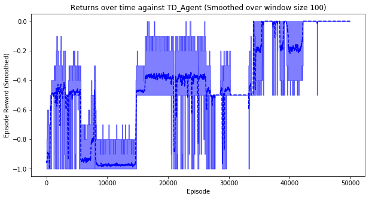

```python
fig = plt.figure(figsize = (10,5))
smoothing_window = 100
a = plotting(mu_on_td,smoothing_window)

plot_mean_and_CI(a[0],a[1],a[2],'b--','b')
plt.xlabel("Episode")
plt.ylabel("Episode Reward (Smoothed)")
plt.title("Returns over time against TD_Agent (Smoothed over window size {})".format(smoothing_window))
plt.show()
```

This is the plot for Number of MC rollouts v/s returns confidence interval among N = 10 games against TD_Agent. Few observations:

- We see that as the number of episodes increases, the expected reward tends to $0$,when playing against the TD_Agent in each epoch.

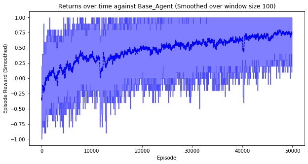

```python
fig = plt.figure(figsize = (10,5))
smoothing_window = 100
a = plotting(mu_on_base,smoothing_window)

plot_mean_and_CI(a[0],a[1],a[2],'b--','b')
plt.xlabel("Episode")
plt.ylabel("Episode Reward (Smoothed)")
plt.title("Returns over time against Base_Agent (Smoothed over window size {})".format(smoothing_window))
plt.show()
```

This is the plot for Number of MC rollouts v/s returns confidence interval among N = 10 games against Base_Agent. Few observations:

- We see that as the number of episodes increases, the expected reward tends to 0.75,when playing against the Base_Agent in each epoch.

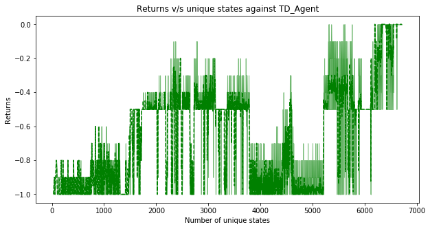

```python
d = defaultdict(lambda: [])

for i in range(len(mc_onpolicy.unique_states)):
    d[mc_onpolicy.unique_states[i]].append(mu_on_td[i])

mu_uniq = []
min_uniq = []
max_uniq = []
for keys in d.keys():
    mu_uniq.append(np.mean(d[keys]))
    min_uniq.append(np.min(d[keys]))
    max_uniq.append(np.max(d[keys]))

mu_uniq = np.array(mu_uniq)
min_uniq = np.array(min_uniq)
max_uniq = np.array(max_uniq)

a = d.keys()
a = list(a)
# a = np.array(a)
# print(a)
fig = plt.figure(figsize = (10,5))
plot_mean_and_CI_2(a,mu_uniq,min_uniq,max_uniq,'g--','g')
# plt.fill_between(range(mu_uniq.shape[0]),max_uniq,min_uniq,'g',.5)
# plt.plot(a,mu_uniq)
plt.xlabel("Number of unique states")
plt.ylabel("Returns")
plt.title("Returns v/s unique states against TD_Agent")
plt.show()
```

This is the plot of unique sates v/s returns among N = 10 games against the TD_Agent. Few observations:

- Expected return tends to 0 as number of unique states increases dring the training iterations.

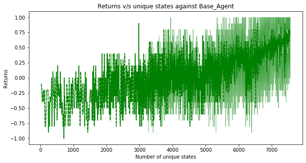

```python
d = defaultdict(lambda: [])

for i in range(len(mc_onpolicy_2.unique_states)):
    d[mc_onpolicy_2.unique_states[i]].append(mu_on_base[i])

mu_uniq = []
min_uniq = []
max_uniq = []
for keys in d.keys():
    mu_uniq.append(np.mean(d[keys]))
    min_uniq.append(np.min(d[keys]))
    max_uniq.append(np.max(d[keys]))

mu_uniq = np.array(mu_uniq)
min_uniq = np.array(min_uniq)
max_uniq = np.array(max_uniq)

a = d.keys()
a = list(a)
# a = np.array(a)
# print(a)
fig = plt.figure(figsize = (10,5))
plot_mean_and_CI_2(a,mu_uniq,max_uniq,min_uniq,'g--','g')
# plt.fill_between(range(mu_uniq.shape[0]),max_uniq,min_uniq,'g',.5)
# plt.plot(a,mu_uniq)
plt.xlabel("Number of unique states")
plt.ylabel("Returns")
plt.title("Returns v/s unique states against Base_Agent")
plt.show()
```

This is the plot of unique sates v/s returns among N = 10 games against the Base_Agent. Few observations:

- Expected return increases as number of unique states increases dring the training iterations.

### Number of unique states v/s Returns is more effective as compared to Number of episodes v/s Returns as it is more intutive to see how the returns are changing with the increase in number of unique states.

```
0.0
```

```
0.0
```

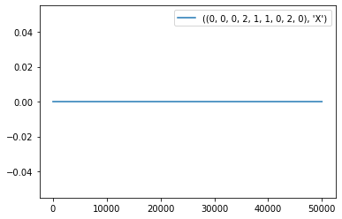

```
0.0
```

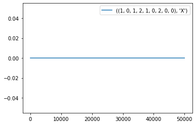

```
0.0
```

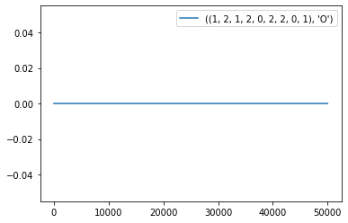

```python
Q_sa_estimator(rndm_state_action,mc_onpolicy)
```

```
0.0
```

```
0.0
```

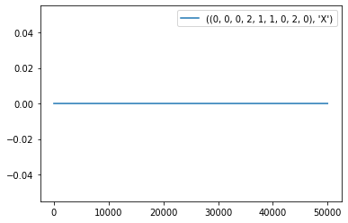

```
0.24983359000000008
```

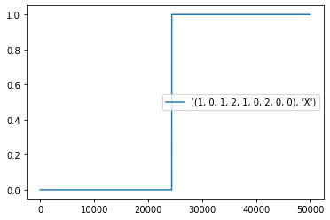

```
0.15215616000000004
```

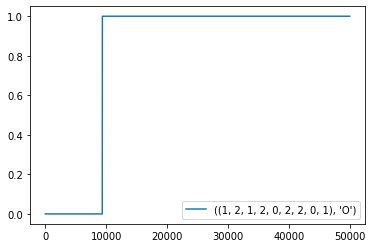

```python
Q_sa_estimator(rndm_state_action,mc_onpolicy_2)
```

### Plots for the $Q(s,a)$ values over the training iterations for some random $(state,action)$ pairs for training with TD_Agent and Base_Agent.

```python
rndm_state_action = [[((0,0,0,1,2,0,0,2,1),'O'),1],[((0,0,0,2,1,1,0,2,0),'X'),1],[((1,0,1,2,1,0,2,0,0),'X'),1],[((1,2,1,2,0,2,2,0,1),'O'),4]]
mc_offpolicy = mc_agents.MC_OffPolicy_Weighted_Importance('O',env,1.0)
mc_offpolicy_2 = mc_agents.MC_OffPolicy_Weighted_Importance('O',env,1.0)
```

```python
mu_off_td = mc_offpolicy.learn(env,50000,td_agent_,rndm_state_action)
```

```
Episode 50000/50000
```

```python
mu_off_base = mc_offpolicy_2.learn(env,50000,base_agent_,rndm_state_action)
```

```
Episode 50000/50000
```

### Initialize the Off Policy MC agent with Mark as $'O'$ and discount factor $\gamma = 1.0$.

### Make the agent learn for N = $50000$ epochs and in each epoch play M = $10$ games with the TD_Agent.

#### The above agent is a Monte-Carlo agent with Off-policy Control with Weighted Importance Sampling.

Few Implementation details:

- Q(state,action) matrix is initialized to zeros and a random $\epsilon$-greedy target policy $\pi_{\epsilon}$ and a random behavioural policy $\mu$ is chosen at the start of the training.
- In each epoch of training, a random episode is generated using the behavioural policy.(Basically,we make the MC agent compete with itself to generate the episode.)
- For each $(state = s,action = a)$ in the episode, we store the discounted reward from the first occurence of $(s,a)$ in $G$ and W which was initialized to $1$ is updated as follows: \begin{equation} W = W\times \frac{\pi_{\epsilon}(s,a)}{\mu(s,a)} \end{equation} Therefore,if $W$ is not updated that is $\pi_{\epsilon}(s,a) = 0$,then we break.
- We also keep track of the cumulated sum of $W$, which is required for the $Q(s,a)$ update.
- Finally, we update $Q[s][a]$ as:

\begin{equation} Q[s][a] = Q[s][a] + \frac{W}{C[s][a]}\big\{G - Q[s][a]\big\} \\ \end{equation}

- The target policy $\pi_{\epsilon}$ is updated according to the updated $Q(s,a)$ values.
- In the above agent we choose to play as $'O'$ and during training $X$ and $O$ are made to play alternatively.
- We choose weigthed importance sampling as opposed to ordinary importance sampling as the variance of ordinary importance sampling rewards can tend to $\infty$.

```python
# mc_agents.load_model('Mc_OffPolicy_agent.dat',mc_offpolicy)
```

[output not shown]

```python
mc_agents.play_against(mc_offpolicy,td_agent_,3000,False)
```

```
O_WINS = 0,X_WINS = 0,DRAW = 3000
```

```
0.0
```

```python
mc_agents.play_against(mc_offpolicy,base_agent_,3000,False)
```

```
O_WINS = 2612,X_WINS = 17,DRAW = 371
```

```
0.865
```

```python
mc_agents.play_against(mc_offpolicy_2,td_agent_,3000,False)
```

```
O_WINS = 0,X_WINS = 0,DRAW = 3000
```

```
0.0
```

```python
mc_agents.play_against(mc_offpolicy_2,base_agent_,3000,False)
```

```
O_WINS = 2623,X_WINS = 19,DRAW = 358
```

```
0.868
```

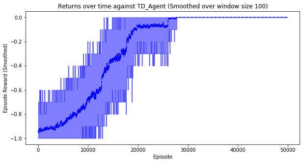

```python
fig = plt.figure(figsize = (10,5))
smoothing_window = 100
a = plotting(mu_off_td,smoothing_window)

plot_mean_and_CI(a[0],a[1],a[2],'b--','b')
plt.xlabel("Episode")
plt.ylabel("Episode Reward (Smoothed)")
plt.title("Returns over time against TD_Agent (Smoothed over window size {})".format(smoothing_window))
plt.show()
```

This is the plot for Number of MC rollouts v/s returns confidence interval among N = 10 games against TD_Agent. Few observations:

- We see that as the number of episodes increases, the expected reward tends to 0.0,when playing against the TD_Agent in each epoch.

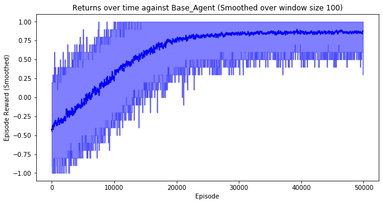

```python
fig = plt.figure(figsize = (10,5))
smoothing_window = 100
a = plotting(mu_off_base,smoothing_window)

plot_mean_and_CI(a[0],a[1],a[2],'b--','b')
plt.xlabel("Episode")
plt.ylabel("Episode Reward (Smoothed)")
plt.title("Returns over time against Base_Agent (Smoothed over window size {})".format(smoothing_window))
plt.show()
```

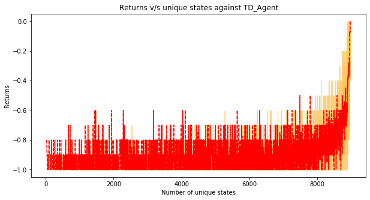

```python
d = defaultdict(lambda: [])

for i in range(len(mc_onpolicy.unique_states)):
    d[mc_offpolicy.unique_states[i]].append(mu_off_td[i])

mu_uniq = []
min_uniq = []
max_uniq = []
for keys in d.keys():
    mu_uniq.append(np.mean(d[keys]))
    min_uniq.append(np.min(d[keys]))
    max_uniq.append(np.max(d[keys]))

mu_uniq = np.array(mu_uniq)
min_uniq = np.array(min_uniq)
max_uniq = np.array(max_uniq)

a = d.keys()
a = list(a)
# a = np.array(a)
# print(a)
fig = plt.figure(figsize = (10,5))
plot_mean_and_CI_2(a,mu_uniq,max_uniq,min_uniq,'r--','orange')
# plt.fill_between(range(mu_uniq.shape[0]),max_uniq,min_uniq,'g',.5)
# plt.plot(a,mu_uniq)
plt.xlabel("Number of unique states")
plt.ylabel("Returns")
plt.title("Returns v/s unique states against TD_Agent")
plt.show()
```

This is the plot of unique sates v/s returns among N = 10 games against the TD_Agent. Few observations:

- Expected return tends to 0 as number of unique states increases dring the training iterations.

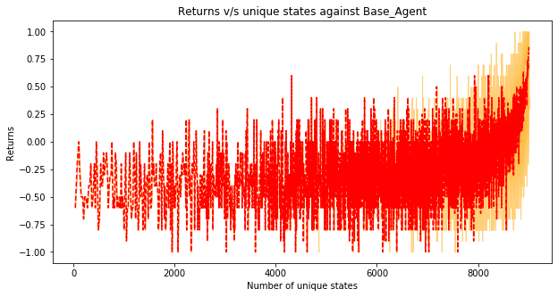

```python
d = defaultdict(lambda: [])

for i in range(len(mc_onpolicy_2.unique_states)):
    d[mc_offpolicy_2.unique_states[i]].append(mu_off_base[i])

mu_uniq = []
min_uniq = []
max_uniq = []
for keys in d.keys():
    mu_uniq.append(np.mean(d[keys]))
    min_uniq.append(np.min(d[keys]))
    max_uniq.append(np.max(d[keys]))

mu_uniq = np.array(mu_uniq)
min_uniq = np.array(min_uniq)
max_uniq = np.array(max_uniq)

a = d.keys()
a = list(a)
# a = np.array(a)
# print(a)
fig = plt.figure(figsize = (10,5))
plot_mean_and_CI_2(a,mu_uniq,max_uniq,min_uniq,'r--','orange')
# plt.fill_between(range(mu_uniq.shape[0]),max_uniq,min_uniq,'g',.5)
# plt.plot(a,mu_uniq)
plt.xlabel("Number of unique states")
plt.ylabel("Returns")
plt.title("Returns v/s unique states against Base_Agent")
plt.show()
```

This is the plot of unique sates v/s returns among N = 10 games against the Base_Agent. Few observations:

- Expected return increases as number of unique states increases dring the training iterations.

### Number of unique states v/s Returns is more effective as compared to Number of episodes v/s Returns as it is more intutive to see how the returns are changing with the increase in number of unique states.

```
0.0
```

```
0.1569017856
```

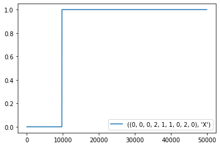

```
0.1354989756
```

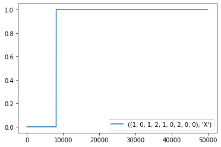

```
0.14800919039999996
```

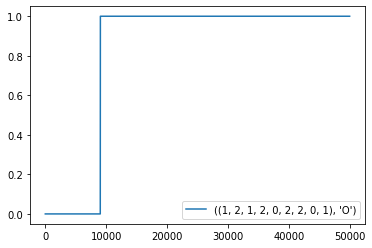

```python
Q_sa_estimator(rndm_state_action,mc_offpolicy)
```

```
0.0
```

```
0.2344648704
```

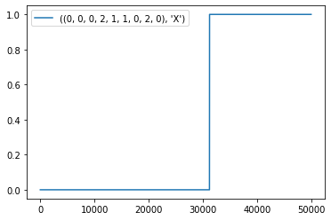

```
0.11737292759999995
```

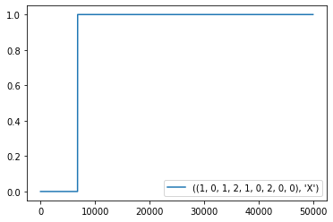

```
0.0053312703999999975
```

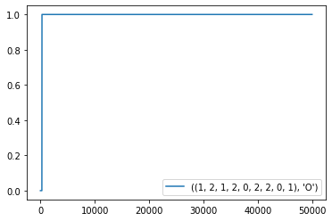

```python
Q_sa_estimator(rndm_state_action,mc_offpolicy_2)
```

## Observations from the above graphs

- Number of MC rollouts v/s return confidence interval
  - Off Policy control agent converges to the optimal value much faster as compared to the On Policy control agent.
  - Both the agents converge to approximately the same accuracy.
- Number of Unique states v/s return confidence interval
  - Essentially, number of unique states depends on the value of $\epsilon$ chosen.
- Value of Q(s,a)
  - A potential problem in off-policy Monte Carlo is that it learns from the tails of episodes. (But, it depends greatly on the choice of behavioural policy $b$ and hence would require an infinite visits to each $(s,a)$ pairs.
  - For example, if the target policy is greedy over the $Q(s,a)$ values, then any exploration will lead to $\delta W$ to be 0, thus leading to break of the loop (as $\pi(a|s)$ is 0). As a result,it will take a long time to learn.
  - As a result, off policy with weighted importance reduces variance but only learns from tails of episodes whereas in on policy variance is not contolled.

## Question 2.2 Bonus

We observe the graphs of TD_Agent v/s Monte-Carlo agents given above.

### Both Temporal-Difference and Monte-Carlo methods update the value of $Q(s_{t+1},a_{t+1})$ based on values of $Q(s_t,a_t)$. As a result, from the start of the training, these methods donot have any information of any state transitions or rewards

### As Monte-Carlo methods update based on true value of $Q(s,a)$, they learn relatively faster as compared to TD Methods which update on the basis of some estimate of $Q(s,a)$ values and may fail to converge.

### But, Monte-Carlo Methods can suffer from high variance, which means more samples are needed to achieve the same degree of learning as compared to TD.

### We observe that the TD learning is more effective in problems where we can achieve convergence as compared to Monte-Carlo Methods.

References

- Td_agent code and environment code provided in https://github.com/haje01/gym-tictactoe